# Economic Regime Classification

## 1. Perpare Data

Totally we have 9 indices reflecting US economic market performance in this study. Those indices are listed in the code chunk below, in which you will see the name of each index and what it represent for.

```r
indices = c("EHGDUS Index", #US Real GDP (QoQ, %, SAAR)
            "CPI YOY Index", #US CPI (inflation) Urban Consumer YoY NSA
            "CPI CHNG Index", #US CPI (inflation) Urban Consumer MoM SA
            "EHUPUS Index", #US Unemployment Rate (%)
            "INJCJMOM Index", #US Initial Jobless Claims MoM SA
            "IP CHNG Index", #US Industrial Production MoM SA
            "NHCHSTCH Index", #Private Housing Units Started Total Monthly % Change, SA
            "GDP CRCH Index", #US Nominal GDP (QoQ, %, SAAR)
            "NFP TCH Index" #US Employment on Nonfarm Payrolls Total MoM Net Change (SA, Net Monthly Change, thousands)
            )
```

By ploting all indices from 1914 to 2020, we should notice that the data in 2020 is an **outlier**. For example, the US Employment on Nonfarm Payrolls Total MoM Net Change index became extremely volatile in 2020 and not reflect its long-term trend. The US government reported that the economy lost 20.5 million jobs in April, the deepest drop since the Great Depression. Therefore, it’s not rational to include 2020 data in this anlaysis due to the data’s abnormality.

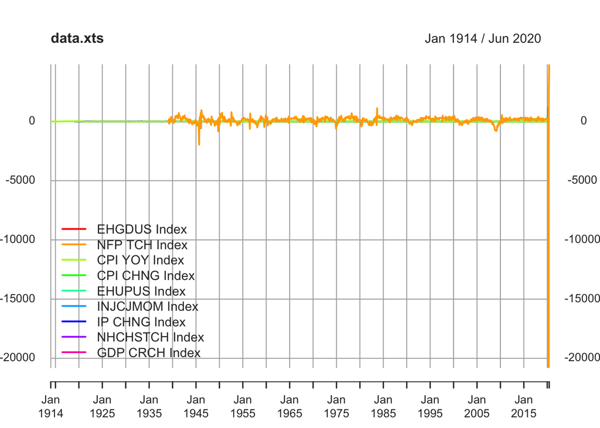

We should also notice that the length of some series started earlier that others and the frequency of some time series are quarterly other than monthly. To solve the inconsistency of time length, I only used data with the longest common history, that is, all data starts in Jan 1967 and ends in Dec 2019. To solve the problem of different frequency, I used the method of linear intepolation to replace the gap in quarterly series by the R package [imputeTS](https://journal.r-project.org/archive/2017/RJ-2017-009/RJ-2017-009.pdf).

[interactive chart not shown]

## Data standardization

Since the absolute value of some variable like US Employment on Nonfarm Payrolls Total MoM Net Change index is much greater than else. In that case, before doing any statistical analysis, in addition to centering each variable, we also multiply it times a constant to make its variance equal to 1, i.e. we standardize each variable.

[interactive chart not shown]

## Data Correlation

Through looking into the correlation between each pairs of standardized indices, we can detect that some of indices are quiet closely related to each other. For example, US Real GDP index is fairly correlated with US Nominal GDP index. Therefore, we can use some dimension reduction techniques in statistics like PCA.

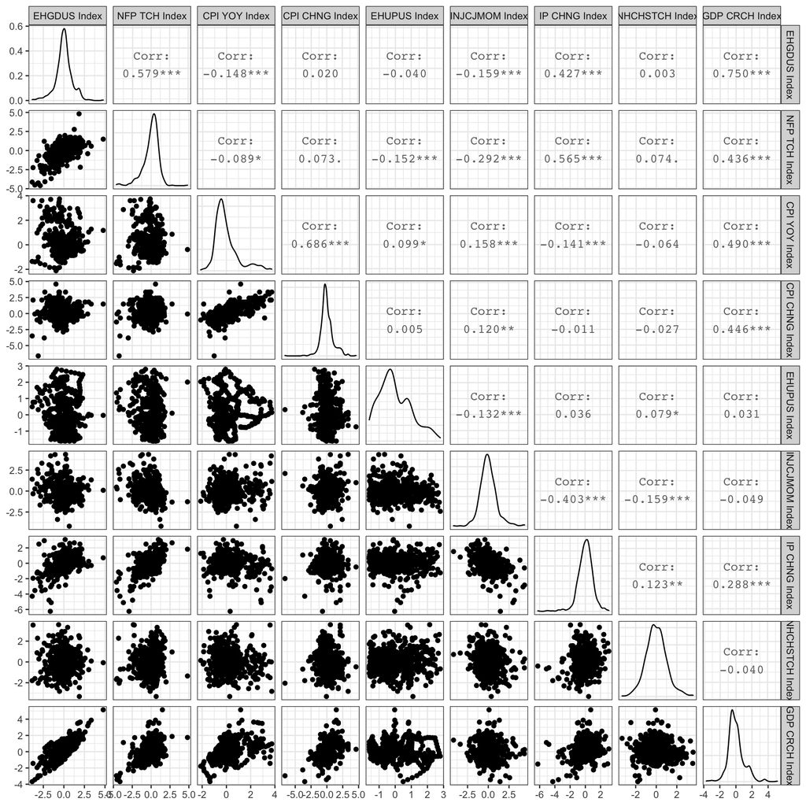

## Classification

### Principle Component Analaysis (PCA)

Monthly data is too repetitious for PCA, as we aim to looking into different historic economic regimes rather than a specific month.

#### Variable contributions to PC

The plot below shows the contributions of variables in accounting for the variability to the top 2 principal components, that is, the higher contribution (%) of one economic index in this graph, the greater necessity to including this index into our analysis.

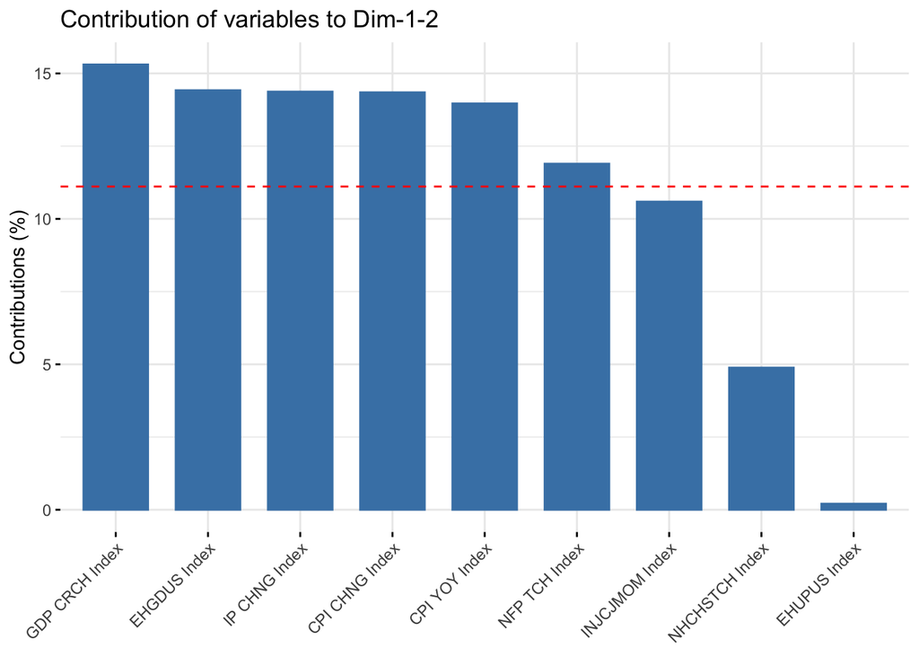

#### Graph of individuals

Individuals with a similar profile are grouped together.

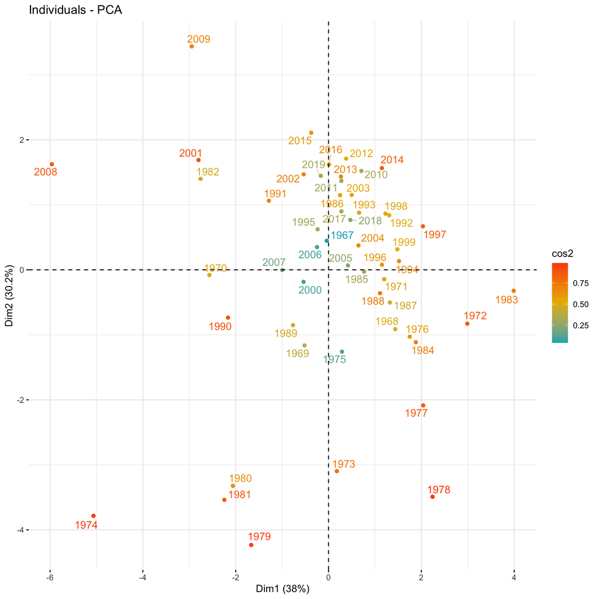

#### Graph of variables

Positive correlated variables point to the same side of the plot. Negative correlated variables point to opposite sides of the graph.

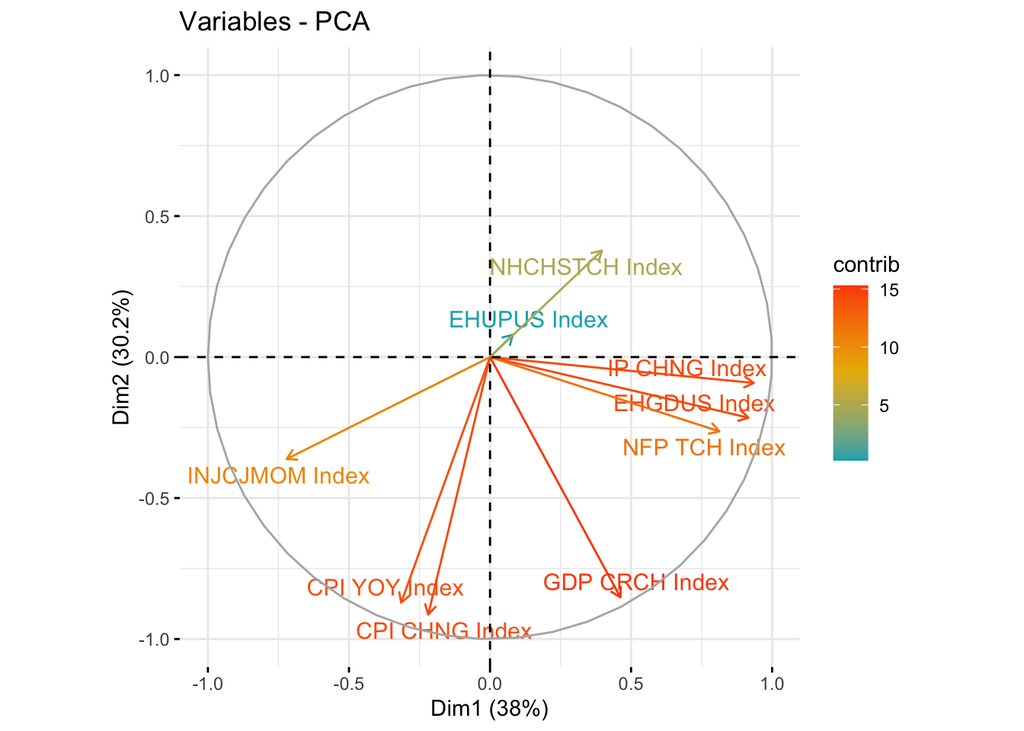

#### Biplot of both individuals and variables

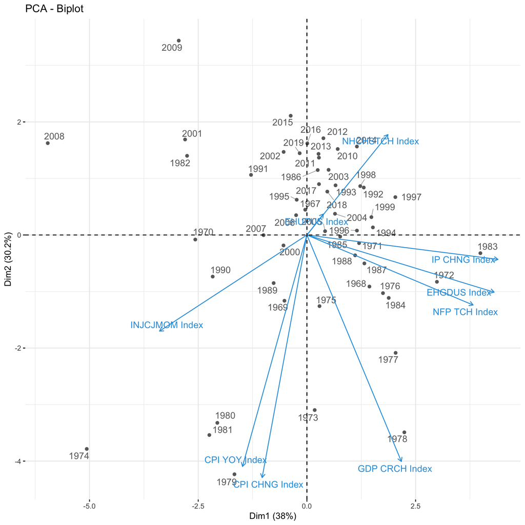